# Sunglasses project - Study 4, preliminary data and prep

Dallas Novakowski

23/26/2019

# Required Packages

```r
library(tidyverse)
data <- read.csv("C:/Users/dalla/Google Drive/R Coding/Shady_Eyes/Legacy_SunglassesStudy4June_2017_namedheaders.csv")
```

## Attention checks

```r
#filter for paperclip attention check, reducing n from 698 to 600
data_att <- filter(data, data$atn_paperclip == 1)
nrow(data_att)
```

```
## [1] 600
```

```r
#"Please carefully look at this advertisement and then answer the following questions. Make sure you read all the information in the ad."
#Reduces n from 600 to 589
data_careful <- filter(data_att, data_att$careful_check == 1)
nrow(data_careful)
```

```
## [1] 589
```

```r
#using the Q42 as a filter (item that describes hypotheses- equivalent to reaching the finish of the study), reduces n from 589 to 564
data_attQ42 <- filter(data_careful, data_careful$Q42 == 1)
nrow(data_attQ42)
```

```
## [1] 564
```

```r
data_finish <- filter(data_att, data_att$Finished == 1)
nrow(data_finish)
```

```
## [1] 414
```

```r
data_att_glasses <- filter(data_attQ42, data_attQ42$p_glasses == 1)
nrow(data_att_glasses)
```

```
## [1] 465
```

using the finished variable seems to be too conservative: generally, participants that scored 0 on the “Finished” variable had responses for all the variables

Moreover, using the item “p_glasses” (“Did the person featured in the advertisement wear glasses?”) might not be appropriate as a filter: some respondents seemed to have interpreted the item as referring to perscription (i.e., clear) glasses

With this in mind, let’s use data_attQ42 as our stopping point for attention checks

## Time to look at ad

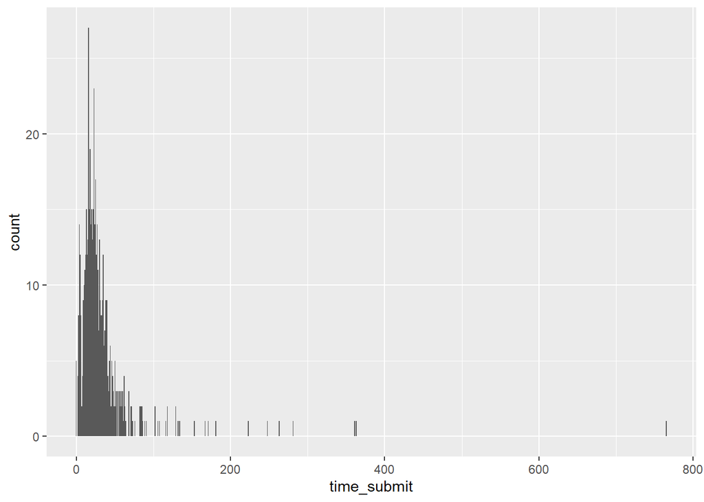

```r
ggplot(data = data_attQ42, aes(x = time_submit)) + geom_histogram(binwidth=1)
```

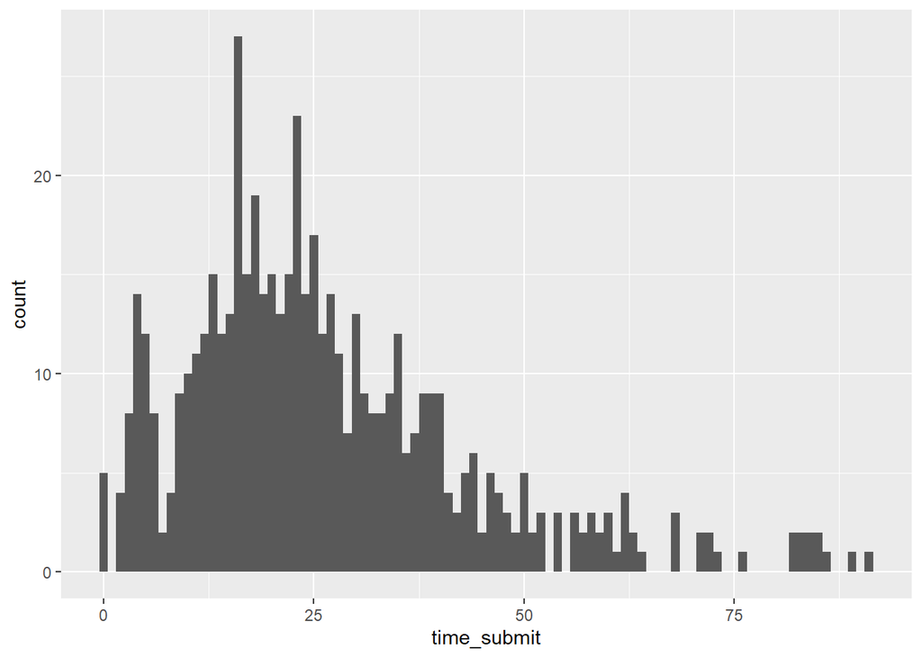

```r
data_timeoutliers <- filter(data_attQ42, data_attQ42$time_submit < 100)
ggplot(data = data_timeoutliers, aes(x = time_submit)) +geom_histogram(binwidth=1)
```

### Looks like a group of respondents took < 10 seconds to look at the ad, let’s filter this group out and run the analyses on the remainder

```r
data_noquickies <- filter(data_attQ42, data_attQ42$time_submit > 10)
nrow(data_noquickies)
```

```
## [1] 492
```

```r
data_noquickies <- as_tibble(data_noquickies)
```

## So now we have an analytic sample of 492 (unless we also want to exclude people that took excessively long)

#Let’s make some variable lists for easier data management down the road

```r
VarBase <- list()
VarBase$conditions <- c('female_clear', 'male_clear', 'female_med', 'female_dark', 'male_med', 'male_dark')
VarBase$demo <- c('gender','age', 'home_lang', 'english_length_nohome', 'wear_glasses', 'employment', 'annual_income', 'education')
VarBase$adrate <- names(data_noquickies)[30:40]
VarBase$productrate <- names(data_noquickies)[41:52]
VarBase$modelrate <- names(data_noquickies)[53:90]
VarBase$consum <- names(data_noquickies)[92:94]
VarBase$adsbeliefs <- names(data_noquickies)[95:102]
VarBase$manipchecks <- names(data_noquickies)[103:105]
```

With the legacy pull in qualtrics, participants’ assigned condition is coded as a binary variable, but we need variables with 2+ levels (namely, shade), so let’s create some new variables for analysis

```r
#change missing values to zeros for condition assignments
data_noquickies[,c(VarBase$conditions)][is.na(data_noquickies[,c(VarBase$conditions)])] <- 0

#create variable for male model (1 = male, 0 = female)
data_noquickies$male_model <- rowSums(cbind(data_noquickies$male_clear, data_noquickies$male_med, data_noquickies$male_dark))

data_noquickies$clear_shade <- rowSums(cbind(data_noquickies$male_clear, data_noquickies$female_clear))
data_noquickies$med_shade <- rowSums(cbind(data_noquickies$male_med, data_noquickies$female_med))
data_noquickies$dark_shade <- rowSums(cbind(data_noquickies$male_dark, data_noquickies$female_dark))

VarBase$shadiness <- c('clear_shade', 'med_shade', 'dark_shade')

#create single variable for shadiness
condition_coding <- function(x, y, z){
      if(x == 1) shade <- 0 else if (y == 1) shade <- 1 else if (z==1) shade <- 2 else shade <- NA
}

data_noquickies$shade <- mapply(condition_coding, x = data_noquickies$clear_shade, y = data_noquickies$med_shade, z = data_noquickies$dark_shade)

VarBase$factors <- c('male_model', 'shade')
VarBase$all <- c(VarBase$demo, VarBase$factors, VarBase$shadiness, VarBase$manipchecks, VarBase$adsbeliefs, VarBase$consum, VarBase$modelrate, VarBase$productrate, VarBase$adrate, VarBase$conditions)
```

Now that we’ve 1) filtered for attention check, time to read the ad, and finishing the survey, 2) made some variable lists, and 3) made some new variables, let’s put make a new dataset that doesn’t make my eyes bleed as much

```r
data_reduced1 <- data_noquickies[,c(VarBase$demo, VarBase$factors, VarBase$shadiness, VarBase$manipchecks, VarBase$adsbeliefs, VarBase$consum, VarBase$modelrate, VarBase$productrate, VarBase$adrate, VarBase$conditions)]

write.csv(data_reduced1, file="C:/Users/dalla/Google Drive/R Coding/Shady_Eyes/sunglasses_Study4_clean1_11_26_2019.csv")

save(data_reduced1, VarBase, file="C:/Users/dalla/Google Drive/R Coding/Shady_Eyes/sunglasses_study4_clean1_11_26_2019.Rdata")
```